# 134000_Alexander Oyatsi_Data Science Final Project

```python
print("The number of students having a maximum score in math:",len(Student.loc[Student["math score"]==100]))
```

```
The number of students having a maximum score in math: 7
```

```python
print("The number of students having a maximum score in writing:",len(Student.loc[Student["writing score"]==100]))
```

```
The number of students having a maximum score in writing: 14
```

```python
print("The number of students having a maximum score in reading:",len(Student.loc[Student["reading score"]==100]))
```

```
The number of students having a maximum score in reading: 17
```

```python
#Perfect Score (Scored 100% in all three categories).
perfect_math_score=Student["math score"]==100
perfect_writing_score=Student["writing score"]==100
perfect_reading_score=Student["reading score"]==100

Perfect_Score=Student.loc[(perfect_math_score)&(perfect_writing_score)&(perfect_reading_score)]
Perfect_Score
```

|  | gender | lunch | test preparation course | math score | reading score | writing score | total_score |
| --- | --- | --- | --- | --- | --- | --- | --- |
| 458 | female | standard | none | 100 | 100 | 100 | 100.0 |
| 916 | male | standard | completed | 100 | 100 | 100 | 100.0 |
| 962 | female | standard | none | 100 | 100 | 100 | 100.0 |

```python
#Number of students with a perfect score (a score of 100).
len(Perfect_Score)
```

```
3
```

```python
#Math Score (According to gender).
print('----Females----')
print('Max. math Score: ', Student[Student['gender'] == 'female']['math score'].max())
print('Min. math Score: ', Student[Student['gender'] == 'female']['math score'].min())
print('Average math Score: ', Student[Student['gender'] == 'female']['math score'].mean())
print('----Males----')
print('Max. math Score: ', Student[Student['gender'] == 'male']['math score'].max())
print('Min. math Score: ', Student[Student['gender'] == 'male']['math score'].min())
print('Average math Score: ', Student[Student['gender'] == 'male']['math score'].mean())
```

```
----Females----
Max. math Score:  100
Min. math Score:  0
Average math Score:  63.633204633204635
----Males----
Max. math Score:  100
Min. math Score:  27
Average math Score:  68.72821576763485
```

```python
#Writing Score (According to gender).
print('----Females----')
print('Max. writing Score: ', Student[Student['gender'] == 'female']['writing score'].max())
print('Min. writing Score: ', Student[Student['gender'] == 'female']['writing score'].min())
print('Average writing Score: ', Student[Student['gender'] == 'female']['writing score'].mean())
print('----Males----')
print('Max. writing Score: ', Student[Student['gender'] == 'male']['writing score'].max())
print('Min. writing Score: ', Student[Student['gender'] == 'male']['writing score'].min())
print('Average writing Score: ', Student[Student['gender'] == 'male']['writing score'].mean())
```

```
----Females----
Max. writing Score:  100
Min. writing Score:  10
Average writing Score:  72.46718146718146
----Males----
Max. writing Score:  100
Min. writing Score:  15
Average writing Score:  63.31120331950208
```

```python
#Reading Score (According to gender).
print('----Females----')
print('Max. reading Score: ', Student[Student['gender'] == 'female']['reading score'].max())
print('Min. reading Score: ', Student[Student['gender'] == 'female']['reading score'].min())
print('Average reading Score: ', Student[Student['gender'] == 'female']['reading score'].mean())
print('----Males----')
print('Max. reading Score: ', Student[Student['gender'] == 'male']['reading score'].max())
print('Min. reading Score: ', Student[Student['gender'] == 'male']['reading score'].min())
print('Average reading Score: ', Student[Student['gender'] == 'male']['reading score'].mean())
```

```
----Females----
Max. reading Score:  100
Min. reading Score:  17
Average reading Score:  72.60810810810811
----Males----
Max. reading Score:  100
Min. reading Score:  23
Average reading Score:  65.47302904564316
```

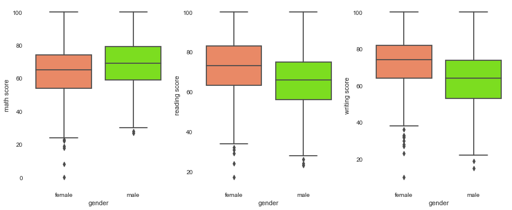

```python
#Box Plots
plt.figure(figsize=(12,5))

plt.subplot(1,3,1)
sns.boxplot(x = 'gender', y = 'math score', data = Student,palette = ['coral', 'lawngreen'])

plt.subplot(1,3,2)
sns.boxplot(x = 'gender', y = 'reading score', data = Student,palette = ['coral', 'lawngreen'])

plt.subplot(1,3,3)
sns.boxplot(x = 'gender', y = 'writing score', data = Student,palette = ['coral', 'lawngreen'])

plt.tight_layout()
plt.savefig("All categories.png")
```

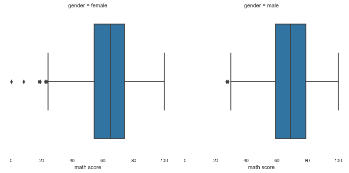

```python
#Math Score Box Plot according to gender.
plt.figure(figsize=(10,8))
sns.catplot(x="math score",kind="box",col="gender",data=Student)
plt.savefig("Box Plot.png")
```

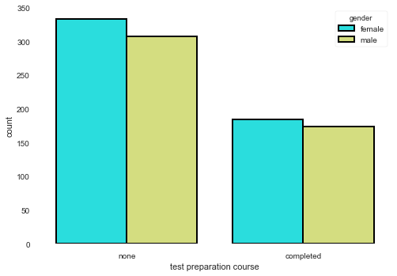

```python
sns.countplot(x="test preparation course",hue="gender",data=Student,palette="rainbow",saturation=1,edgecolor=(0,0,0),linewidth=2)
```

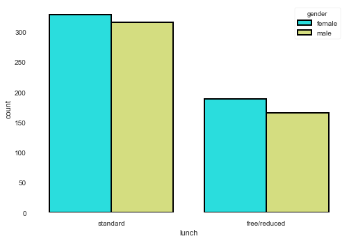

```python
sns.countplot(x="lunch",hue="gender",data=Student,palette="rainbow",saturation=1,edgecolor=(0,0,0),linewidth=2)
```

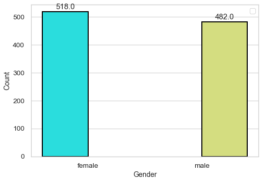

```python
#Gender Count
sns.set(font_scale=1.25)
sns.set_style('whitegrid')
splot=sns.countplot(x="gender",hue="gender",data=Student,palette="rainbow",saturation=1,edgecolor=(0,0,0),linewidth=2)
for p in splot.patches:
    splot.annotate(format(p.get_height(), '.1f'),
                   (p.get_x() + p.get_width() / 2., p.get_height()),
                   ha = 'center', va = 'center',
                   size=15,
                   xytext = (0, 9),
                   textcoords = 'offset points')
plt.xlabel("Gender", size=14)
plt.ylabel("Count", size=14)
plt.legend([])
plt.savefig("Gender Count.png")
```

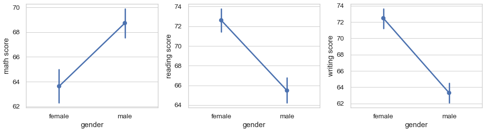

```python
#Point Plots.
plt.figure(figsize=(14,4))
plt.subplot(1,3,1)
sns.pointplot(x = "gender", y = "math score",data= Student)

plt.subplot(1,3,2)
sns.pointplot(x="gender",y="reading score",data=Student)

plt.subplot(1,3,3)
sns.pointplot(x="gender",y="writing score",data=Student)

plt.tight_layout()
plt.savefig("Point Plot.png")
```

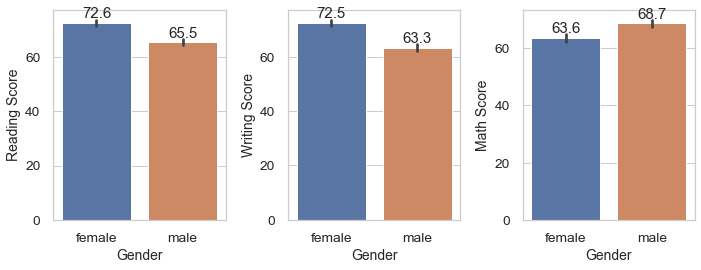

```python
#Bar Plots.
plt.figure(figsize=(10,4))

plt.subplot(1,3,1)
splot=sns.barplot(x = 'gender', y = 'reading score', data = Student)
for p in splot.patches:
    splot.annotate(format(p.get_height(), '.1f'),
                   (p.get_x() + p.get_width() / 2., p.get_height()),
                   ha = 'center', va = 'center',
                   size=15,
                   xytext = (0, 9),
                   textcoords = 'offset points')
plt.xlabel("Gender", size=14)
plt.ylabel("Reading Score", size=14)

plt.subplot(1,3,2)
splot=sns.barplot(x = 'gender', y = 'writing score', data = Student)
for p in splot.patches:
    splot.annotate(format(p.get_height(), '.1f'),
                   (p.get_x() + p.get_width() / 2., p.get_height()),
                   ha = 'center', va = 'center',
                   size=15,
                   xytext = (0, 9),
                   textcoords = 'offset points')
plt.xlabel("Gender", size=14)
plt.ylabel("Writing Score", size=14)

plt.subplot(1,3,3)
splot=sns.barplot(x = 'gender', y = 'math score', data = Student)
for p in splot.patches:
    splot.annotate(format(p.get_height(), '.1f'),
                   (p.get_x() + p.get_width() / 2., p.get_height()),
                   ha = 'center', va = 'center',
                   size=15,
                   xytext = (0, 9),
                   textcoords = 'offset points')
plt.xlabel("Gender", size=14)
plt.ylabel("Math Score", size=14)

plt.tight_layout()
plt.savefig("Bar Plot Comparison")
```

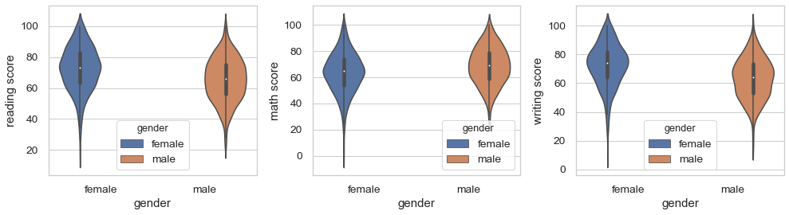

```python
#Violin Plots.
plt.figure(figsize=(14,4))
plt.subplot(1,3,1)
ax=sns.violinplot(x="gender",y="reading score",hue="gender",data=Student)
plt.subplot(1,3,2)
ax=sns.violinplot(x="gender",y="math score",hue="gender",data=Student)
plt.subplot(1,3,3)
ax=sns.violinplot(x="gender",y="writing score",hue="gender",data=Student)
plt.tight_layout()
plt.savefig("Gender violin Plot")
```

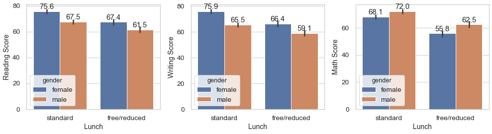

```python
#Bar Plots acccording to Lunch.
plt.figure(figsize=(14,4))

plt.subplot(1,3,1)
splot=sns.barplot(x = 'lunch', y = 'reading score', hue = 'gender', data = Student)
for p in splot.patches:
    splot.annotate(format(p.get_height(), '.1f'),
                   (p.get_x() + p.get_width() / 2., p.get_height()),
                   ha = 'center', va = 'center',
                   size=15,
                   xytext = (0, 9),
                   textcoords = 'offset points')
plt.xlabel("Lunch", size=14)
plt.ylabel("Reading Score", size=14)

plt.subplot(1,3,2)
splot=sns.barplot(x = 'lunch', y = 'writing score',hue = 'gender', data = Student)
for p in splot.patches:
    splot.annotate(format(p.get_height(), '.1f'),
                   (p.get_x() + p.get_width() / 2., p.get_height()),
                   ha = 'center', va = 'center',
                   size=15,
                   xytext = (0, 9),
                   textcoords = 'offset points')
plt.xlabel("Lunch", size=14)
plt.ylabel("Writing Score", size=14)

plt.subplot(1,3,3)
splot=sns.barplot(x = 'lunch', y = 'math score',hue = 'gender', data = Student)
for p in splot.patches:
    splot.annotate(format(p.get_height(), '.1f'),
                   (p.get_x() + p.get_width() / 2., p.get_height()),
                   ha = 'center', va = 'center',
                   size=15,
                   xytext = (0, 9),
                   textcoords = 'offset points')
plt.xlabel("Lunch", size=14)
plt.ylabel("Math Score", size=14)

plt.tight_layout()
plt.savefig("Lunch.png")
```

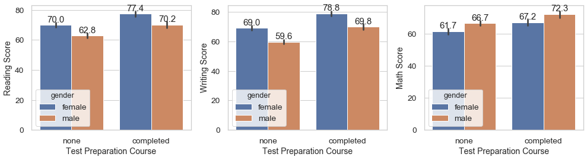

```python
#Bar Plots according to Test Preparation Score.
plt.figure(figsize=(14,4))

plt.subplot(1,3,1)
splot=sns.barplot(x = 'test preparation course', y = 'reading score', hue = 'gender', data = Student)
for p in splot.patches:
    splot.annotate(format(p.get_height(), '.1f'),
                   (p.get_x() + p.get_width() / 2., p.get_height()),
                   ha = 'center', va = 'center',
                   size=15,
                   xytext = (0, 9),
                   textcoords = 'offset points')
plt.xlabel("Test Preparation Course", size=14)
plt.ylabel("Reading Score", size=14)

plt.subplot(1,3,2)
splot=sns.barplot(x = 'test preparation course', y = 'writing score',hue = 'gender', data = Student)
for p in splot.patches:
    splot.annotate(format(p.get_height(), '.1f'),
                   (p.get_x() + p.get_width() / 2., p.get_height()),
                   ha = 'center', va = 'center',
                   size=15,
                   xytext = (0, 9),
                   textcoords = 'offset points')
plt.xlabel("Test Preparation Course", size=14)
plt.ylabel("Writing Score", size=14)

plt.subplot(1,3,3)
splot=sns.barplot(x = 'test preparation course', y = 'math score',hue = 'gender', data = Student)
for p in splot.patches:
    splot.annotate(format(p.get_height(), '.1f'),
                   (p.get_x() + p.get_width() / 2., p.get_height()),
                   ha = 'center', va = 'center',
                   size=15,
                   xytext = (0, 9),
                   textcoords = 'offset points')
plt.xlabel("Test Preparation Course", size=14)
plt.ylabel("Math Score", size=14)

plt.tight_layout()
plt.savefig("Test Preparation Course.png")
```

```python
passing_marks = 40
Student['Pass_Status'] = np.where(Student['total_score']<passing_marks,'F','P')
Student['Pass_Status'].value_counts()
```

```
P    970
F     30
Name: Pass_Status, dtype: int64
```

```python
Student.head(2)
```

|  | gender | lunch | test preparation course | math score | reading score | writing score | total_score | Pass_Status |
| --- | --- | --- | --- | --- | --- | --- | --- | --- |
| 0 | female | standard | none | 72 | 72 | 74 | 72.666667 | P |
| 1 | female | standard | completed | 69 | 90 | 88 | 82.333333 | P |

Implementing a Grading system for marks obtained. The grading system is described as follows:

1. A+ (Excellent): Student who scores 82 marks or higher in a subject
2. A (Very Good): Student who scores 73 marks or higher in a subject
3. B+ (Good): Student who scores 64 marks or higher in a subject
4. B (Above Average): Student who scores 55 marks or higher in a subject
5. C (Average): Student who scores 46 marks or higher in a subject
6. P (Pass): Student who scores 35 marks or higher in a subject
7. F (Fail): Student who scores less than 35 marks in a subject

```python
#Assigning Grades.
# Function to assign grades.

def get_grade(marks):
    if marks >= 82 and marks <= 100:
        return 'A+'
    elif marks >=73 and marks < 82:
        return 'A'
    elif marks >=64 and marks < 73:
        return 'B+'
    elif marks >= 55 and marks < 64:
        return 'B'
    elif marks >=46 and marks < 55:
        return 'C'
    elif marks >= 35 and marks < 46:
        return 'P'
    elif marks < 35:
        return 'F'
```

```python
#Assigning Grades Continuation.
Student['Reading Grade'] = Student['reading score'].apply(get_grade)
Student['Writing Grade'] = Student['writing score'].apply(get_grade)
Student['Math Grade'] = Student['math score'].apply(get_grade)
```

```python
def grades(pass_status,total_score):
    if pass_status == 'F':
        return 'F'
    if total_score >=90:
        return 'A+'
    if total_score >=80:
        return 'A'
    if total_score >=70:
        return 'B'
    if total_score >=60:
        return 'C'
    if total_score >=50:
        return 'D'
    if total_score >=40:
        return 'E'
```

```python
Student['Grade'] =Student.apply(lambda x : grades(x['Pass_Status'] ,x['total_score']) ,axis =1)
Student.head(2)
```

|  | gender | lunch | test preparation course | math score | reading score | writing score | total_score | Pass_Status | Reading Grade | Writing Grade | Math Grade | Grade |
| --- | --- | --- | --- | --- | --- | --- | --- | --- | --- | --- | --- | --- |
| 0 | female | standard | none | 72 | 72 | 74 | 72.666667 | P | B+ | A | B+ | B |
| 1 | female | standard | completed | 69 | 90 | 88 | 82.333333 | P | A+ | A+ | B+ | A |

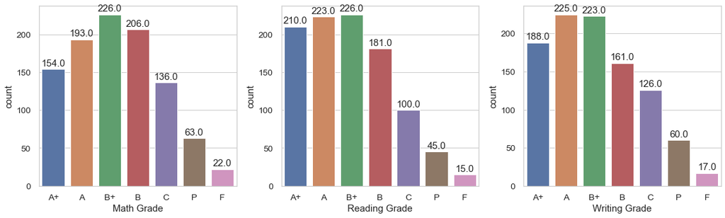

```python
#Assigning Grades Continuation.
sns.set_style('whitegrid')
plt.figure(figsize=(16,5))
plt.subplot(1,3,1)
splot=sns.countplot(x ='Math Grade', data = Student,order = ['A+','A','B+','B','C','P','F'],palette='deep')
for p in splot.patches:
    splot.annotate(format(p.get_height(), '.1f'),
                   (p.get_x() + p.get_width() / 2., p.get_height()),
                   ha = 'center', va = 'center',
                   size=15,
                   xytext = (0, 9),
                   textcoords = 'offset points')
plt.subplot(1,3,2)
splot=sns.countplot(x ='Reading Grade', data = Student,order = ['A+','A','B+','B','C','P','F'],palette='deep')
plt.subplot(1,3,1)
for p in splot.patches:
    splot.annotate(format(p.get_height(), '.1f'),
                   (p.get_x() + p.get_width() / 2., p.get_height()),
                   ha = 'center', va = 'center',
                   size=15,
                   xytext = (0, 9),
                   textcoords = 'offset points')
plt.subplot(1,3,3)
splot=sns.countplot(x ='Writing Grade', data = Student,order = ['A+','A','B+','B','C','P','F'],palette='deep')
for p in splot.patches:
    splot.annotate(format(p.get_height(), '.1f'),
                   (p.get_x() + p.get_width() / 2., p.get_height()),
                   ha = 'center', va = 'center',
                   size=15,
                   xytext = (0, 9),
                   textcoords = 'offset points')
plt.tight_layout()
plt.savefig("Grade Count Plot.png")
```

```python
#Establishing the number of students who attained a perfect grade.
perfect_writing = Student['Writing Grade'] == 'A+'
perfect_reading = Student['Reading Grade'] == 'A+'
perfect_math = Student['Math Grade'] == 'A+'

perfect_grade = Student[(perfect_math) & (perfect_reading) & (perfect_writing)]
print('Number of students having maximum grade(A+) in all three subjects: ',len(perfect_grade))
```

```
Number of students having maximum grade(A+) in all three subjects:  95
```

```python
#Establishing the number of students who attained the least grade in all three categries.
minimum_math = Student['Math Grade'] == 'F'
minimum_reading = Student['Reading Grade'] == 'F'
minimum_writing = Student['Writing Grade'] == 'F'



minimum_grade = Student[(minimum_math) & (minimum_reading) & (minimum_writing)]
print('Number of students having minimum grade(F) in all three subjects: ',len(minimum_grade))
```

```
Number of students having minimum grade(F) in all three subjects:  8
```

```python
#Failed Students
failed_students = Student[(minimum_math) | (minimum_reading)|(minimum_writing)]
failed = len(failed_students)
print('Total Number of students who failed are: {}' .format(len(failed_students)))
```

```
Total Number of students who failed are: 29
```

```python
#Passed Students
passed_students = len(Student) - len(failed_students)
print('Total Number of students who passed are: {}' .format(passed_students))
```

```
Total Number of students who passed are: 971
```

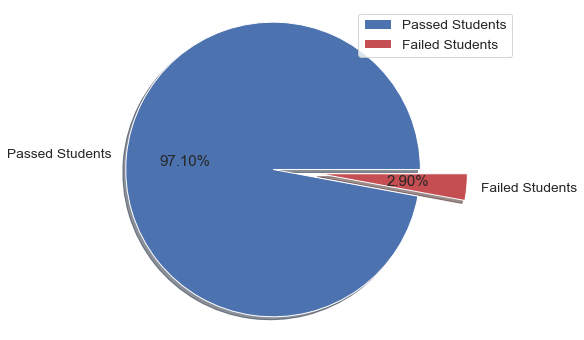

```python
#Pie chart to illustrate all the data above (passed students and failed students).
plt.figure(figsize=(8,6))

#Data to plot
labels = 'Passed Students', 'Failed Students'
sizes = [passed_students,failed]
colors = ['b','r']
explode = (0.32,0.0)

#Plot
plt.pie(sizes,explode = explode, labels = labels,colors = colors,
       autopct='%.2f%%',shadow = True, startangle=360)
plt.axis('equal')

plt.legend()
plt.savefig("piechart.png")
plt.show()
```

# Linear Regression Modelling Using Scikit Learn.

```python
from sklearn.linear_model import LogisticRegression
```

```python
from sklearn import linear_model
```

```python
X_shaped=Student["math score"].values
```

```python
X_shaped=Student["math score"].values.reshape(-1,1)
X_shaped
```

[output not shown]

[output cut: 945 more lines]

[output not shown]

```python
Y_shaped=Student["total_score"].values.reshape(-1,1)
Y_shaped
```

[output not shown]

[output cut: 945 more lines]

[output not shown]

```python
#Our next step is to divide the data into “attributes” and “labels”.
#Attributes are the independent variables while labels are dependent variables whose values are to be predicted.
#We want to predict the total_score depending upon the math score recorded.
X_shaped=Student["math score"].values.reshape(-1,1)
Y_shaped=Student["total_score"].values.reshape(-1,1)
```

```python
#random state can be any number.
#Next, we split 80% of the data to the training set while 20% of the data to test set using below code.
#The test_size variable is where we actually specify the proportion of the test set.
from sklearn.model_selection import train_test_split
x_train,x_test,y_train,y_test=train_test_split(X_shaped,Y_shaped,test_size=0.2,random_state=0)
print(x_train.shape)
print(x_test.shape)
print(y_train)
print(y_test)
```

[output not shown]

[output cut: 947 more lines]

[output not shown]

# Initializing the model

```python
from sklearn.linear_model import LinearRegression
lm=LinearRegression()
```

# Fitting the model

```python
#After splitting the data into training and testing sets, finally, the time is to train our algorithm.
lm.fit(x_train,y_train)
```

```
LinearRegression()
```

```python
#finds the best value for the intercept.
Intercept=lm.intercept_
print(f"the y-intercept is:{Intercept}")
```

```
the y-intercept is:[10.64277615]
```

```python
#finds the best value for the Coefficient.
Coefficient=lm.coef_
print(f"the Coefficient is:{Coefficient}")
```

```
the Coefficient is:[[0.8657433]]
```

Now that we have trained our algorithm, it’s time to make some predictions. To do so, we will use our test data and see how accurately our algorithm predicts the percentage score.

```python
# making the predictions using the predict function.
y_pred = lm.predict(x_test)
```

```python
type(y_pred)
```

```
numpy.ndarray
```

Lets make a comparison between the actual values for x_test and the predicted values.

```python
comparison_df = pd.DataFrame({'Actual':y_test.flatten(),'Predicted':y_pred.flatten()})
comparison_df
```

|  | Actual | Predicted |
| --- | --- | --- |
| 0 | 69.333333 | 64.318861 |
| 1 | 77.333333 | 85.962443 |
| 2 | 45.333333 | 45.272508 |
| 3 | 67.666667 | 77.305010 |
| 4 | 74.333333 | 70.379064 |
| ... | ... | ... |
| 195 | 61.333333 | 65.184604 |
| 196 | 84.000000 | 74.707780 |
| 197 | 80.666667 | 83.365213 |
| 198 | 69.666667 | 66.916091 |
| 199 | 66.000000 | 64.318861 |

200 rows × 2 columns

Visualizing the comparison result as a bar graph. Note: As the number of records is huge, for representation purpose I’m taking just 25 records.

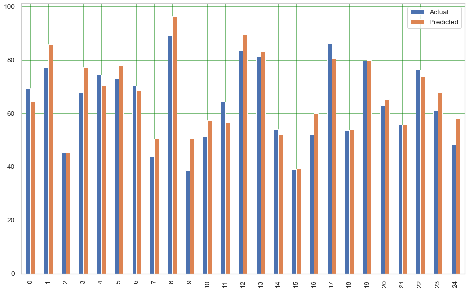

```python
df1 = comparison_df.head(25)
df1.plot(kind='bar',figsize=(16,10))
plt.grid(which='major', linestyle='-', linewidth='0.5', color='green')
plt.grid(which='minor', linestyle=':', linewidth='0.5', color='black')
plt.show()
```

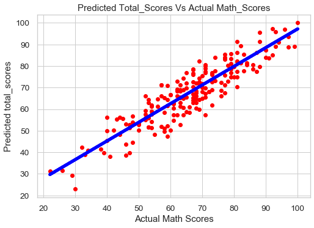

```python
# Plotting the line of best fit.
plt.scatter(x_test, y_test,  color='red')
plt.plot(x_test, y_pred, color='blue', linewidth=5)
plt.ylabel("Predicted total_scores",fontsize=15)
plt.xlabel("Actual Math Scores",fontsize=15)
plt.title("Predicted Total_Scores Vs Actual Math_Scores")
plt.savefig("mini-project.png")
plt.show()
```

The final step is to evaluate the performance of the algorithm. This step is particularly important to compare how well different algorithms perform on a particular dataset. For regression algorithms, three evaluation metrics are commonly used:

```python
from sklearn import metrics
print('Mean Absolute Error:', metrics.mean_absolute_error(y_test, y_pred))
print('Mean Squared Error:', metrics.mean_squared_error(y_test, y_pred))
print('Root Mean Squared Error:', np.sqrt(metrics.mean_squared_error(y_test, y_pred)))
```

```
Mean Absolute Error: 4.950906780017983
Mean Squared Error: 36.13800474366885
Root Mean Squared Error: 6.011489394789685
```